# RR-Project1

Wednesday, March 11, 2015

This report contains the analysis of the activity monitoring data specified for this assignment.

First Load the data:

```r
steps=read.csv("activity.csv")
summary(steps)
```

```
##      steps                date          interval
##  Min.   :  0.00   2012-10-01:  288   Min.   :   0.0
##  1st Qu.:  0.00   2012-10-02:  288   1st Qu.: 588.8
##  Median :  0.00   2012-10-03:  288   Median :1177.5
##  Mean   : 37.38   2012-10-04:  288   Mean   :1177.5
##  3rd Qu.: 12.00   2012-10-05:  288   3rd Qu.:1766.2
##  Max.   :806.00   2012-10-06:  288   Max.   :2355.0
##  NA's   :2304     (Other)   :15840
```

It can be seen that the “steps” column contains some NAs. As instructed we will be imputing the NA’s later on in the assignment and ignoring them for the time-being.

### Analysis of Total Steps Per Day

Calculating Total Nr. of Steps taken per day

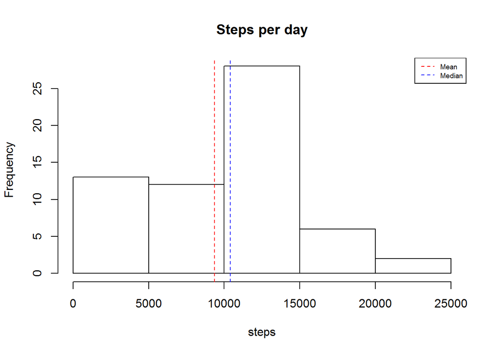

```r
#steps_pd=rowsum(steps$steps,steps$date,na.rm=T)
#hist(steps_pd)
#meanSteps = mean(steps_pd)
#medianSteps = median(steps_pd)
#abline(v=meanSteps, col="red", lty=2)
#abline(v=medianSteps, col="blue", lty=2)
#legend("topright", legend=c("Mean", "Median"), lty=c(2,2), col=c("red","blue"), cex=0.6)
myHist <- function (df){
  steps_pd=rowsum(df$steps,df$date,na.rm=T)
  hist(steps_pd, main="Steps per day", xlab="steps")
  meanSteps = mean(steps_pd)
  medianSteps = median(steps_pd)
  abline(v=meanSteps, col="red", lty=2)
  abline(v=medianSteps, col="blue", lty=2)
  legend("topright", legend=c("Mean", "Median"), lty=c(2,2), col=c("red","blue"), cex=0.6)
  c(meanSteps,medianSteps)
}

summ_steps = myHist(steps)
```

### Analysing Average Daily Activity Pattern

```r
#Following library needed for by function.
library(taRifx)
#create smaller dataframe without the NAs
small_steps=steps[!is.na(steps$steps),]

#Average the NAs over the column interval
steps_avg_int = as.data.frame(by(small_steps$steps, small_steps$interval, mean))

#The following did not work. Hence used the by function from taRifx
#steps_avg_int=aggregate(x=c(steps$steps), by=as.list(steps$interval), FUN=mean, na.action=na.omit)

#Plot the timeseries of average steps over intervals
```

The following plot show the average step pattern along a series of 5 min intervals in a day

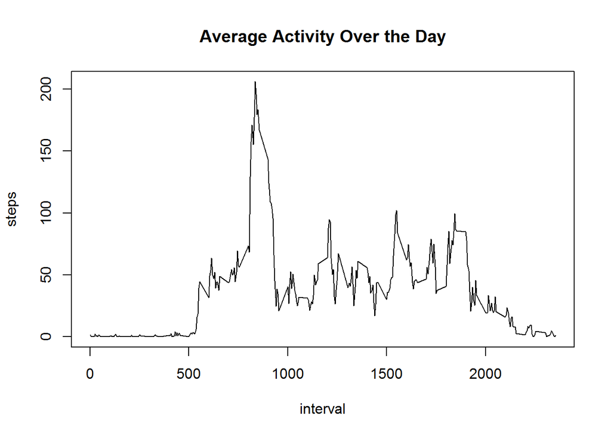

```r
plot(steps_avg_int$IDX1,steps_avg_int$value, type="l", xlab="interval", ylab="steps", main="Average Activity Over the Day")
```

```r
#determine the interval containing the max average steps
max_steps = max(steps_avg_int$value)
max_steps_interval = steps_avg_int[steps_avg_int$value==max_steps,]$IDX1
```

The **835 th interval** contains the maximum nr. of steps in a day.